TRexSelector R package guide

# The ML methods

# The building blocks

The machine learning (ML) methods are the numerical building blocks the selectors use: scalers, ridge and elastic-net regression with cross-validation (the $\lambda_2$ tuners), the singular value decomposition (SVD) and principal component analysis (PCA) behind the sparse PCA selector, and the hierarchical clustering behind the dependency-aware and the grouped selectors. They are exposed as classes and functions of their own, built on Eigen [1].

```r
set.seed(8)
n <- 120
p <- 30
X <- matrix(rnorm(n * p), n, p)
beta <- c(2, -1.5, 0, 0, 1, rep(0, p - 5))
y <- as.numeric(X %*% beta + rnorm(n))
```

# Scalers

`MLZScoreScaler` centers and divides by the sample standard deviation, `MLLpNormScaler` centers and divides by the L1 or L2 norm. Both work in place on a double matrix (or a memory-mapped one) and can undo their transformation.

```r
z <- MLZScoreScaler$new()
z$fit(X)
round(z$get_centers()[1:3], 3)
```

```
#> [1] -0.103  0.009 -0.104
```

```r
round(z$get_scales()[1:3], 3)
```

```
#> [1] 1.067 1.008 1.007
```

```r
X_before <- X + 0
invisible(z$transform_inplace(X))
round(colMeans(X)[1:3], 12)
```

```
#> [1] 0 0 0
```

```r
round(apply(X, 2, sd)[1:3], 12)
```

```
#> [1] 1 1 1
```

```r
invisible(z$inverse_transform_inplace(X))
max(abs(X - X_before))
```

```
#> [1] 4.440892e-16
```

`fit_transform_inplace()` does both in one call, `get_dropped_indices()` names constant columns, and `save()` / `load()` persist the statistics.

```r
l2 <- MLLpNormScaler$new(norm_type = 2, center = TRUE)
invisible(l2$fit_transform_inplace(X))
sqrt(colSums(X^2))[1:3]
```

```
#> [1] 1 1 1
```

```r
invisible(l2$inverse_transform_inplace(X))
```

# Ridge regression

`MLRidge` solves $\min_{\boldsymbol\beta} \|\boldsymbol y - \boldsymbol X \boldsymbol\beta\|_2^2 + \lambda \|\boldsymbol\beta\|_2^2$ for one penalty [2], by the primal or the dual Cholesky path depending on the shape of `X`. `MLRidgeCV` chooses the penalty by $K$-fold cross-validation over a geometric grid and reports the minimum and the one-standard-error rule.

```r
ridge <- MLRidge$new()
round(ridge$solve(X, y, lambda = 1)[1:5], 3)
```

```
#> [1]  2.143 -1.639 -0.159  0.077  0.920
```

```r
cv <- MLRidgeCV$new()
cv$fit(X, y, n_folds = 5, n_lambda = 50)
c(lambda_min = cv$cv_min(), lambda_1se = cv$cv_1se())
```

```
#> lambda_min lambda_1se
#> 0.08377766 0.25877608
```

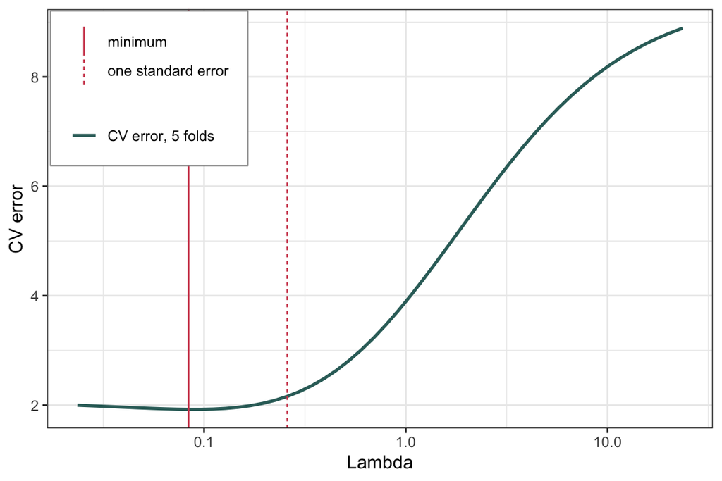

Cross-validation error of the ridge penalty with the minimum and the one-standard-error choice.

```r
library(ggplot2)
curve <- data.frame(lambda = cv$get_lambdas(), error = cv$get_cv_errors())
choice <- data.frame(lambda = c(cv$cv_min(), cv$cv_1se()), rule = c("minimum", "one standard error"))
ggplot(curve, aes(lambda, error)) +
  geom_line(aes(colour = "CV error, 5 folds"), linewidth = 0.9) +
  geom_vline(data = choice, aes(xintercept = lambda, linetype = rule), colour = "#D1495B") +
  scale_x_log10() +
  scale_colour_manual(values = c("CV error, 5 folds" = "#336C68")) +
  labs(x = "Lambda", y = "CV error", colour = NULL, linetype = NULL) +
  theme_bw(base_size = 11) +
  theme(legend.position = "inside", legend.position.inside = c(0.02, 0.98),
        legend.justification = c(0, 1), legend.background = element_blank(),
        legend.box.background = element_rect(fill = "white", colour = "grey60"),
        legend.box.margin = margin(4, 6, 4, 6))
```

`MLRidgeCV$new(low_memory = TRUE)` runs the dual (kernel) form on column blocks of `X` read in place, with memory $O(n^2)$ instead of $O(np)$, the route for $p \gg n$.

# The elastic net

`MLElasticNet` fits the elastic-net path [3] by coordinate descent over a glmnet-style grid [4]. `alpha = 1` is the lasso, `alpha = 0` the ridge. The coefficients are reported on the original scale.

```r
en <- MLElasticNet$new()
en$fit(X, y, alpha = 0.5, n_lambda = 50)
dim(en$get_coef())
```

```
#> [1] 30 39
```

```r
length(en$get_lambdas())
```

```
#> [1] 39
```

```r
en$converged()
```

```
#> [1] TRUE
```

```r
B <- en$get_coef()               # the path can stop before n_lambda points
round(B[1:5, ncol(B)], 3)
```

```
#> [1]  2.159 -1.650 -0.167  0.071  0.916
```

```r
round(en$predict(X[1:3, ])[, ncol(B)], 3)
```

```
#> [1]  3.120  3.338 -1.793
```

`MLElasticNetCV` selects the penalty by cross-validation on a shared grid. The strong rules [5] speed up the sweeps.

```r
encv <- MLElasticNetCV$new()
encv$fit(X, y, alpha = 0.5, n_folds = 5, n_lambda = 50)
c(lambda_min = encv$cv_min(), lambda_1se = encv$cv_1se())
```

```
#> lambda_min lambda_1se
#>  0.2125322  0.4507704
```

Both classes accept `low_memory = TRUE` and then run on `X` itself, a memory-mapped matrix included, without an allocation of the size of `X`.

# SVD and PCA

`MLSVD$new()$compute(X, M)` returns the top-$M$ truncated SVD, by a direct, a Gram or a randomized path depending on the shape of `X`.

```r
svd_res <- MLSVD$new()$compute(X, M = 3)
names(svd_res)
```

```
#> [1] "U" "S" "V"
```

```r
dim(svd_res$U)
```

```
#> [1] 120   3
```

```r
round(svd_res$S, 3)
```

```
#> [1] 16.113 14.803 14.607
```

`MLPCA` fits the top-$M$ components. It centers and normalizes `X` in place at construction, the same rule as the T-solvers, and `restore()` undoes it.

```r
X_before <- X + 0
pca <- MLPCA$new(X, M = 3, center = TRUE, normalize = TRUE)
pca$fit()
dim(pca$get_scores())
```

```
#> [1] 120   3
```

```r
dim(pca$get_loadings())
```

```
#> [1] 30  3
```

```r
round(pca$get_explained_variance(), 3)
```

```
#> [1] 0.016 0.015 0.014
```

```r
round(pca$transform(X_before[1:2, ]), 3)
```

```
#>        [,1]   [,2]   [,3]
#> [1,]  0.056  0.143 -0.064
#> [2,] -0.140 -0.067  0.073
```

```r
pca$restore()
max(abs(X - X_before))
```

```
#> [1] 4.440892e-16
```

# Hierarchical clustering

`ml_agglomerative_cluster()` runs agglomerative clustering on the rows of a matrix with a linkage from `ml_linkage_method` (Ward, average, complete, single, WPGMA, median, centroid) and a metric from `ml_distance_metric` (Euclidean, correlation, Manhattan, and two locality-sensitive hashing (LSH) variants of the correlation distance for very wide data). Single linkage runs the SLINK algorithm [6], the other linkages the nearest-neighbour chain [7], [8] with the Lance-Williams update [9]. The result is a linkage matrix, and `ml_cut_tree()` cuts it into a given number of clusters.

```r
set.seed(9)
centers <- rep(c(-3, 0, 3), each = 20)
Z <- centers + matrix(rnorm(60 * 4), 60, 4)
linkage <- ml_agglomerative_cluster(Z, method = ml_linkage_method$Ward,
                                    metric = ml_distance_metric$Euclidean)
dim(linkage)
```

```
#> [1] 59  4
```

```r
labels <- ml_cut_tree(linkage, num_orig_objs = 60, num_clusters = 3)
table(labels, rep(1:3, each = 20))
```

```
#>
#> labels  1  2  3
#>      1 20  0  0
#>      2  0  1 20
#>      3  0 19  0
```

To cluster variables instead of observations, cluster the transposed design with the correlation distance, which is what the grouped and the dependency-aware selectors do.

```r
link_vars <- ml_agglomerative_cluster(t(X), method = ml_linkage_method$Single,
                                      metric = ml_distance_metric$Correlation)
head(ml_cut_tree(link_vars, num_orig_objs = p, num_clusters = 5))
```

```
#> [1] 1 1 1 2 1 1
```

`use_mmap = TRUE` keeps the intermediate distances in memory-mapped files, and a memory-mapped `data` matrix is clustered in place.

# Examples

The [TRexSelector_Examples](https://github.com/trexselector/TRexSelector_Examples/tree/main) repository holds runnable demos and Monte Carlo studies of the scalers, ridge and elastic-net cross-validation, PCA, SVD and clustering, with their results and a README per demo, in [R](https://github.com/trexselector/TRexSelector_Examples/tree/main/R/ml_methods), [Python](https://github.com/trexselector/TRexSelector_Examples/tree/main/Python/ml_methods) and [C++](https://github.com/trexselector/TRexSelector_Examples/tree/main/cpp/ml_methods).

# Bibliography

[1]

G. Guennebaud, B. Jacob, *et al.*, “Eigen v3.” 2010. Available: https://libeigen.gitlab.io/

[2]

A. E. Hoerl and R. W. Kennard, “Ridge regression: Biased estimation for nonorthogonal problems,” *Technometrics*, vol. 42, no. 1, pp. 80–86, 2000, doi: 10.1080/00401706.2000.10485983.

[3]

H. Zou and T. Hastie, “Regularization and variable selection via the elastic net,” *J. R. Stat. Soc. Ser. B Stat. Methodol.*, vol. 67, no. 2, pp. 301–320, 2005, doi: 10.1111/j.1467-9868.2005.00503.x.

[4]

J. Friedman, T. Hastie, and R. Tibshirani, “Regularization paths for generalized linear models via coordinate descent,” *J. Stat. Softw.*, vol. 33, no. 1, pp. 1–22, 2010, doi: 10.18637/jss.v033.i01.

[5]

R. Tibshirani *et al.*, “Strong rules for discarding predictors in lasso-type problems,” *J. R. Stat. Soc. Ser. B Stat. Methodol.*, vol. 74, no. 2, pp. 245–266, 2012, doi: 10.1111/j.1467-9868.2011.01004.x.

[6]

R. Sibson, “SLINK: An optimally efficient algorithm for the single-link cluster method,” *Comput. J.*, vol. 16, no. 1, pp. 30–34, 1973, doi: 10.1093/comjnl/16.1.30.

[7]

J.-P. Benzécri, “Construction d’une classification ascendante hiérarchique par la recherche en chaîne des voisins réciproques,” *Les Cahiers de l’Analyse des Données*, vol. 7, no. 2, pp. 209–218, 1982.

[8]

F. Murtagh and P. Contreras, “Algorithms for hierarchical clustering: An overview,” *Wiley Interdiscip. Rev. Data Min. Knowl. Discov.*, vol. 2, no. 1, pp. 86–97, 2012, doi: 10.1002/widm.53.

[9]

G. N. Lance and W. T. Williams, “A general theory of classificatory sorting strategies: I. Hierarchical systems,” *Comput. J.*, vol. 9, pp. 373–380, 1967, doi: 10.1093/comjnl/9.4.373.